# Used Car Price Prediction

Used Car Price Prediction

### **Introduction**

This project focuses on **predicting used car prices** by utilizing machine learning algorithms. It is important to understand how the used car prices are being influenced by various features as the market has changed dramatically.

- **Tools:** Python / R
- **Dataset:** CarGurus (IL/IA/WI/MI/IN)
- **Analyses performed:** Linear/Polynomial regression, Random Forest, KNN

### **Data Description and Exploratory Data Analysis**

The data utilized in this project has been collected from the CarGurus website through web-scraping. The selection of our data source has been made on the fact that CarGurus is known to use advanced algorithms to assess the value of any vehicle, making it highly likely that their prices will reflect the features that exist.

```r
knitr::kable(results,caption='Project summary')
```

Project summary

|  | Coefficient.of.Determination | MSE | MAE |
| --- | --- | --- | --- |
| Linear Regression | 78.51% | 49,588,734 | 4154.19 |
| Polynomial Regression | 83.31% | 46,202,202 | 3443.15 |
| Random Forest | 89.24% | 29,780,137 | 2724.70 |
| KNN | 81.83% | 51,542,118 | 3843.28 |

- To investigation for high correlation among features found that there was a very high correlation among features ‘Apple CarPlay’ and ‘AndroidAuto’.

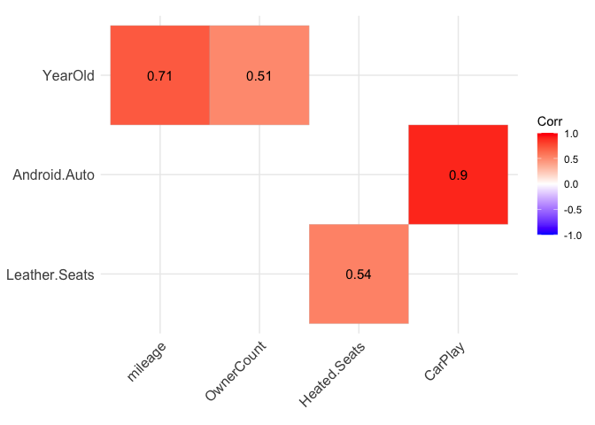

- After recognizing high correlation between AndroidAuto and CarPlay, there was need to check Variance Inflation Factor(VIF) to adjust our subset of variables to be used in the analysis. To compare the VIF in a broader scale among the variables, we calculated the VIF for the two set of highly correlated variables, which added the pair of YearOld and Mileage. As a result we were able to find that Carplay and AndroidAuto had VIF over 10 whereas the pair with the second largest correlation had VIF less than 10. Setting our threshold of VIF as 10, there was need to make adjustment to CarPlay and AndroidAuto due to multicollinearity.
- Despite the VIF of CarPlay being larger, we still chose to keep CarPlay in our analysis and drop AndroidAuto. This decision was based on the research on market share that cellphone manufacturers have in the United States. Apple had over 50% market share which made it more realistic to use CarPlay over AndroidAuto.

```r
knitr::kable(vif,caption='Variance Inflation Factor')
```

Variance Inflation Factor

| Variables | PriorVIF | PosteriorVIF |
| --- | --- | --- |
| CarPlay | 12.465760 | 1.184677 |
| Android Auto | 12.215435 | – |
| YearOld | 6.697340 | 6.690461 |
| mileage | 6.702101 | 6.9698865 |

- Relationship between the price and features Mileage, YearOld, AccidentCount, and OwnerCount all showed a negative relationship.

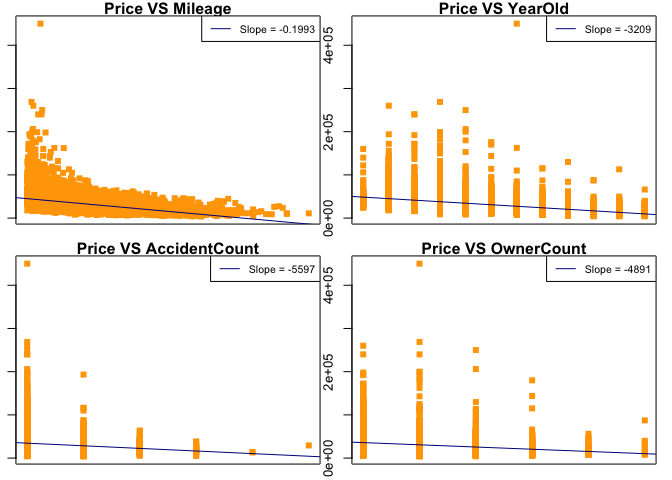

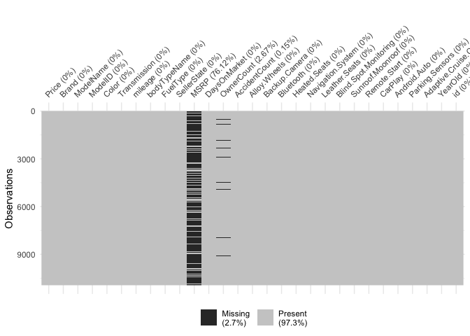

- Analysis on the Brand feature revealed that the most number of brands within the dataset was that of Ford and Chevrolet, while the highest priced Brand were Lamborghini and Ferrari.
- After basic observation of our data, we preceded to perform encoding the categorical features. The two choices of encoding possible, one-hot encoding and target encoding, were considered for all categorical variables and based on the number of different factors possible, we have set the threshold at 17 additional columns to be acceptable to keep the total number of columns below 45 for the sake of computational efficiency. As a result, one-hot encoding was implemented to features Transmission and FuelType, while target encoding was implemented to Brand, ModelID, Color, and BodyType.

## Section 4: Methodology

- The ML algorithm considered for application in this project has been restricted to those of Linear Regression, Polynomial Regression, Random Forest, and K-Nearest Neighbor. These algorithms have been selected on the characteristic that they have that can be distinguishable characteristic against others.
- Linear Regression has been chosen as it is the most fundamental and essential regression possible, making it crucial approach that should be considered in many data. It is also capable of analyzing the linearity of the data that can be overlooked by other approaches.
- Polynomial Regression was selected to account the characteristic of our data. Our data can not be considered completely linear which hence, the prediction accuracy could be increased by applying polynomial regression. However, there is a change that over fitting will occur and requires careful attention through out our analysis.
- Random Forest was selected to with respect to numerous feature that our data has. Random forest is able to account for numerous features while ensuring that the each final nodes will be uncorrelated.
- K-Nearest Neighbor was selected so that we could apply supervised machine learning algorithm to our analysis. The KNN can be applied to solve both classification and regression problems. In our analysis, we applied the KNN algorithm for regression.
  - For the KNN we found that just using encoding method would reduce the accuracy of our model. Therefore, we scaled the data. In the methods of scaling to be used in KNN analysis, we implemented 3 possible methods.
    - The min-max method which uses minimum and maximum values of a feature to re scale values
    - The standard method of scaling features to be approximately standard normally distributed.
    - The robust scaling method which can overcome outliers within the data. This is acquired by using the first and third quartile values in the scaling process.
  - Among these methods three choices, we found that robust scaling method returned the highest $R^2$ score.

```r
knn = data.frame(
  "Method" = c("Before Scaling","Min-Max scaling","Standard Scaling","Robust Scaling"),
  "R squared" = c("77.62%","63.56%","76.14%","81.38%")
)
```

```r
knitr::kable(knn,caption='KNN Scaling')
```

KNN Scaling

| Method | R.squared |
| --- | --- |
| Before Scaling | 77.62% |
| Min-Max scaling | 63.56% |
| Standard Scaling | 76.14% |
| Robust Scaling | 81.38% |

## Section 5 : Analysis results

- Through our analysis, we have had to find the appropriate tuning parameters to be used within some of our selected models. Such tuning parameters will be explained in the corresponding description of algorithms.
- For the linear regression, our analysis returned the $R^2$ score of 0.7851 which is 78.51% of accuracy. For the polynomial regression $R^2$ was 0.8331, 83.31% accuracy.
- In the random forest algorithm, we had to perform a randomized grid search to find the appropriate number of estimator and the minimum number of samples required to split an internal node. We focused our selection based on $R^2$ that could be acquired as our main goal was to compare against other algorithms. As a result we were able to get a combination of 300 estimators and split to be at 4. The final result that we acquire was $R^2$ of 0.8924, 89.24%.

Project summary

|  | Coefficient.of.Determination | MSE | MAE |
| --- | --- | --- | --- |
| Linear Regression | 78.51% | 49,588,734 | 4154.19 |
| Polynomial Regression | 83.31% | 46,202,202 | 3443.15 |
| Random Forest | 89.24% | 29,780,137 | 2724.70 |
| KNN | 81.83% | 51,542,118 | 3843.28 |

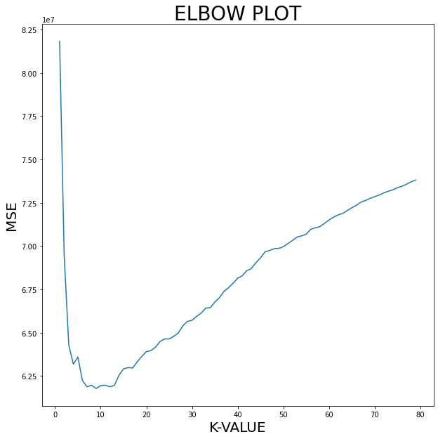

```r
knitr::include_graphics(path = "elbow.png")
```

- The following plot shows how close the predicted prices were compared to the actual prices

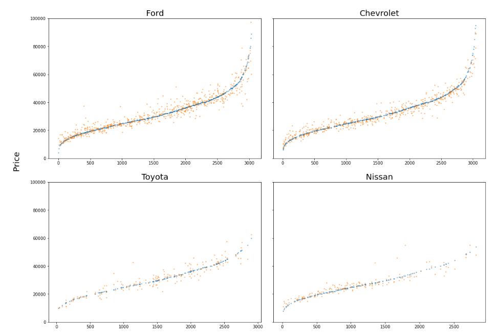

```r
#prediction and actual
knitr::include_graphics(path = "result_4table.png")
```

- The effective algorithm for our dataset was random forest. So to investigate how much each feature was contributing to our prediction, we calculated the feature importance. As shown below, ModelID, YearOld, mileage, and Brand consisted over 90% of the feature importance. The obtained result shows that used car buyers should focus on these top four features.

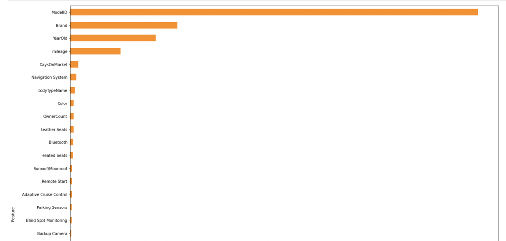

```r
#prediction and actual
knitr::include_graphics(path = "featureimpt.jpeg")
```

## Section 6 : Discussion

- The existence of NULL values in our data has caused much nuisance. Especially for the feature MSRP as we initially thought that MSRP would be a key factor in price prediction. Without additional information regarding MSRP, we could not replace these NULL values with others as it would lead to tampering with data. Therefore, we believe that if we were able to find a way to gather MSRP information through past dataset and merge it with the dataset that we used, it would likely improve our prediction.
- The model that has been used in the analysis of this dataset has aspects in which it can be implemented to other relevant data. Having found that the feature importance is concentrated on ModelID, YearOld, Mileage, and Brand, the same feature importance can be found in used airplane market as well. With the emergence of lower priced airline that operates using second-hand airplanes, this model may be helpful in predicting the future price for second-hand airplane buyers.
- This project has only utilized four of numerous possible algorithms that could have been implemented. Despite our selection of these are based on their characteristics and may reflect how others may perform as well, performance of other algorithms cannot be determined beforehand. Other algorithms such as that of XGBoost have been found to show great performance in other works that have been used in our reference. Therefore comparison using those models may lead to better discovery of better prediction levels.

## Reference

1. Chuancan Chen, Lulu Hao, and Cong Xu , *“Comparative analysis of used car price evaluation models”*, AIP Conference Proceedings 1839, 020165, 2017
2. Xinyuan Zhang, Zhiye Zhang, and Changtong Qiu, *“Model of Predicting the Price Range of Used Car”*, 2017
3. Nabarun Pal, Priya Arora, Sai Sumanth Palakurthy, Dhanasekar Sundararaman, Puneet Kohli, *“How much is my car worth? A methodology for predicting used cars prices using Random Forest”*, Future of Information and Communications Conference (FICC), 2018
4. Pattabiraman Venkatasubbu, Mukkesh Ganesh, *“Used Cars Price Prediction using Supervised Learning Techniques”*, International Journal of Engineering and Advanced Technology (IJEAT), 2019
5. Kshitij Kumbar, Pranav Gadre, Varun Nayak, *“CS 229 Project Report: Predicting Used Car Prices”*, 2019